# L1-maps1

wj107

April 1, 2019

# Learning to map in R!

I learned `ggmap` a couple years back, but never got beyond making a couple extremely basic maps. There’s more to learn – experimenting in a notebook seems like a viable approach. I need to talk (type) out my ideas, and the code needs to, well… map.

### Data

I need some geographical data to represent on a map. A brief Google search yielded a [JSON file](https://gist.github.com/Miserlou/c5cd8364bf9b2420bb29) giving coordinates, population, and growth rates for the 1000 most populous cities in the United States. A quick download, and I’ve got my data! Hat tip to [Rich Jones](https://gist.github.com/Miserlou) for providing the data.

### Importing Data

Ok, I learned once before JSON is some sort of data structure. JSON vs. XML vs. XLSX vs. data frames… I have no ideas about the differences between them all. But, I figured one can convert to the other. So, Google “JSON to data frame R” and without clicking any results, I could see my end game: `jsonlite` package, and a `fromJSON` command.

```r
#---import data from 1000 most populous US cities in 2013
require(jsonlite,quietly=T)
fromJSON("data/cities.json")->dat

#---preview
head(dat)
```

```
##           city growth_from_2000_to_2013 latitude  longitude population
## 1     New York                     4.8% 40.71278  -74.00594    8405837
## 2  Los Angeles                     4.8% 34.05223 -118.24368    3884307
## 3      Chicago                    -6.1% 41.87811  -87.62980    2718782
## 4      Houston                    11.0% 29.76043  -95.36980    2195914
## 5 Philadelphia                     2.6% 39.95258  -75.16522    1553165
## 6      Phoenix                    14.0% 33.44838 -112.07404    1513367
##   rank        state
## 1    1     New York
## 2    2   California
## 3    3     Illinois
## 4    4        Texas
## 5    5 Pennsylvania
## 6    6      Arizona
```

There’s some fun numbers in there that I’ll revisit later (growth rate!!). But, for now, I want to get those cities on a basic US map.

Googling “ggplot map” and I find a [tidy little tutorial](https://eriqande.github.io/rep-res-web/lectures/making-maps-with-R.html) that just might be my crutch for the rest of this coding session. Of course, I’m not interested in going through the tutorial step-by-step. But, I’ll steal some chunks of it, deduce what’s going on, and then bend it back to my data frame. Hat tip to [Eric Anderson](https://eriqande.github.io) for the tutorial!

First code snippet I’ll steal from the tutorial:

`usa <- map_data("usa") ggplot() + geom_polygon(data = usa, aes(x=long, y = lat, group = group)) + coord_fixed(1.3)`

Looks like `map_data` (from the `ggplot2` package) is importing a map, which then is represented using the `geom_polygon` call. I’m curious to examine the structure of `usa` also.

And, you know, I’ve never used `coord_fixed` before. Tutorial tells me it’s fixing the aspect ratio. I figure I would have come across that before, or at least have searched it out myself.

```r
#---required
require(ggplot2, quietly=T)

#---get usa map data
usa <- map_data("usa")

#---what's a map_data output look like?
head(usa)
```

```
##        long      lat group order region subregion
## 1 -101.4078 29.74224     1     1   main      <NA>
## 2 -101.3906 29.74224     1     2   main      <NA>
## 3 -101.3620 29.65056     1     3   main      <NA>
## 4 -101.3505 29.63911     1     4   main      <NA>
## 5 -101.3219 29.63338     1     5   main      <NA>
## 6 -101.3047 29.64484     1     6   main      <NA>
```

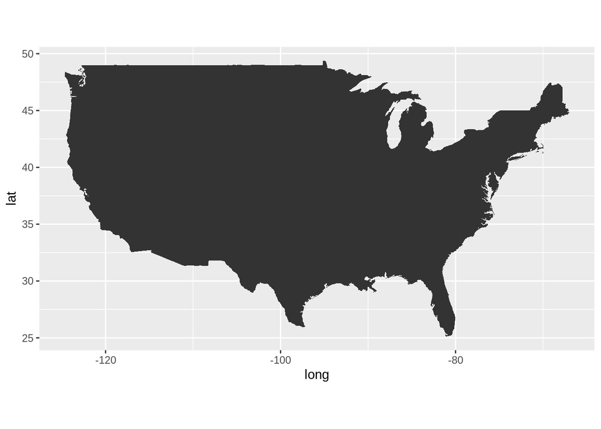

```r
#---create a usa map
usa_map<-
  #---with ggplot!!!
  ggplot() +
    #---the map is a polygon...
    geom_polygon(
        #---with usa data
        data = usa,
        #---aesthetics!!
        aes(
            #---lat & long coordinates
            x=long,
            y = lat,
            #---okay I need to remember how to use 'group'
            group = group)
    ) +
  #---fix aspect ratio!  1.3 : 1 , y: x
  coord_fixed(1.3)

#---PLOT!!!
usa_map
```

Okay! I get it – the points are plotted (x and y aesthetics) and `geom_polygon` aims to connect these dots and fill them in… but it’s got to connect and group the dots properly. Hence the `group` aesthetic: it’s telling `geom_polygon` which dots to group together. So, there must be different values for `usa$group` for the teeny islands in Puget Sound, or Nantucket, or Long Island.

In particular, running `unique(usa$group)` tells me there’s TEN different groups, or there’s ten different landforms to represent – I suppose that’d be nine notable islands and the US mainland. Wonder how Alaska and Hawaii (and Puerto Rico!) feel about that…

### A couple solo maps

Yeah, I was going to plot those 1000 most populous cities. I’ll get to it. But I’m awfully intrigued by the `map_data` command. Obviously I could go all day learning about that. But, given the structure of the output (lots of `xy`-coordinates marking a boundary), could I represent using other geometries, instead of `geom_polygon`? Let’s try, using boundary data for Illinois.

```r
#---get map data for all 50 states
states<-map_data("state")
#---subset just Illinois data
IL<-subset(states,region=="illinois")
```

First I tried `map_data("Illinois")`… no luck. I need to get all 50 states, then subset.

```r
#---base map for Illinois!
IL.basemap<-
  #---create w.ggplot
  ggplot(
    #---IL boundary data
    data=IL,
    #---aesthetics -- lat and long
    aes(
        #---careful... x= long, y=lat
        x=long,
        y=lat
    )
  )+
#---don't mess with that aspect ratio!!!
coord_fixed()
```

I messed up at first: `x` is longitude, `y` is latitude… Rookie mistake.

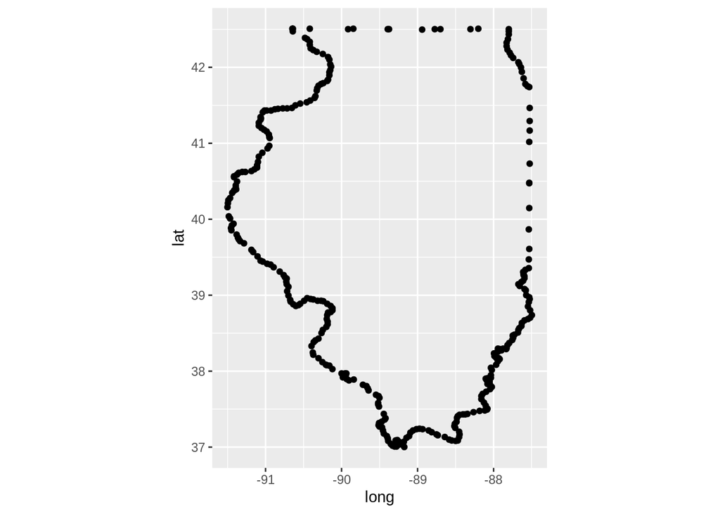

```r
####################################################
#---represent base map with various geometries...

#---behaved as expected.
IL.basemap+geom_point()
```

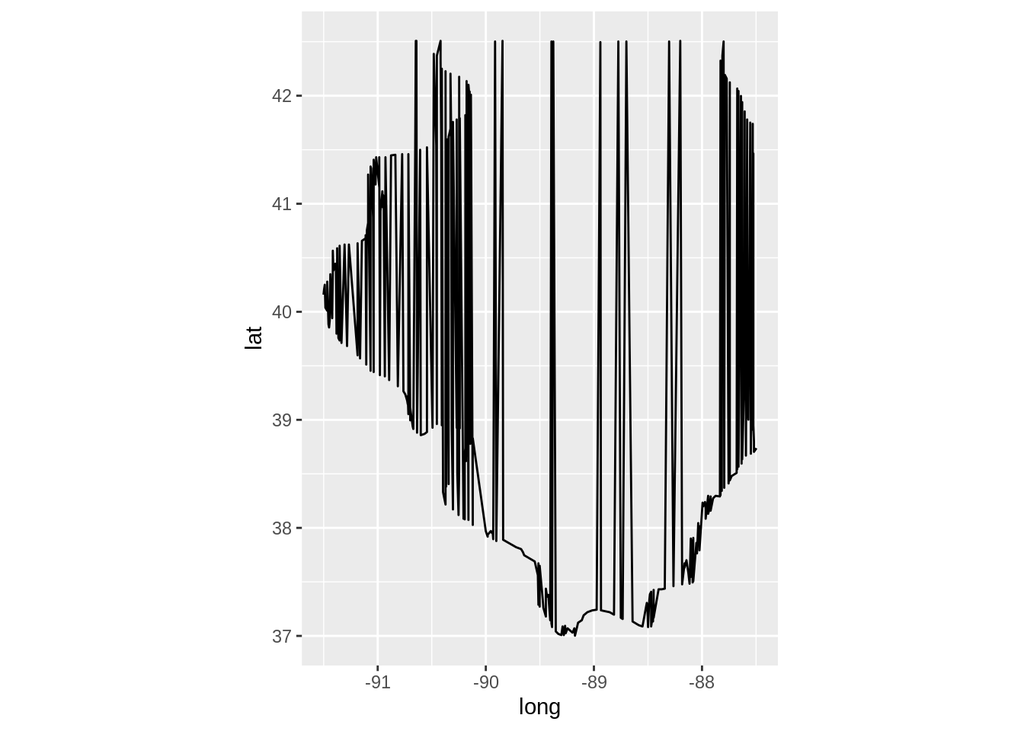

```r
#---not what I expected, at all!!  Super cool, though--but I wonder why it's doing that.
IL.basemap+geom_line()
```

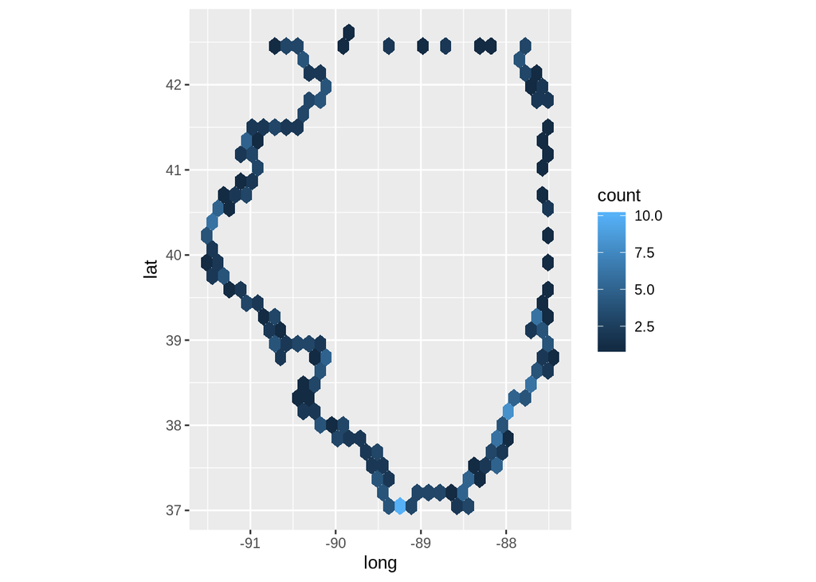

```r
#---HA! lighter-colored hexagons have more 'wavey' regions of the state border.
IL.basemap+geom_hex()
```

(Trying to position those graphs, I learned about [`flexdashboard`](https://bookdown.org/yihui/rmarkdown/layout.html). Add it to the list – someday!!)

The first map is pretty straightforward. The second one – I love it! But, I don’t understand why the line is out of order. I’ll have to investigate the `geom_line` geometry to see if there’s a straightforward way to control the order the line is drawn. The third is a goofy little experiment: how wavey is the border near where you live?

Now, I’m going to find out what’s up with the order `geom_line` draws. I know [where](https://ggplot2.tidyverse.org/reference/index.html#section-layer-geoms) I can find some information…. Without even clicking on `geom_line` I figured it out. There’s a difference between `geom_line` and `geom_path`. Let’s see:

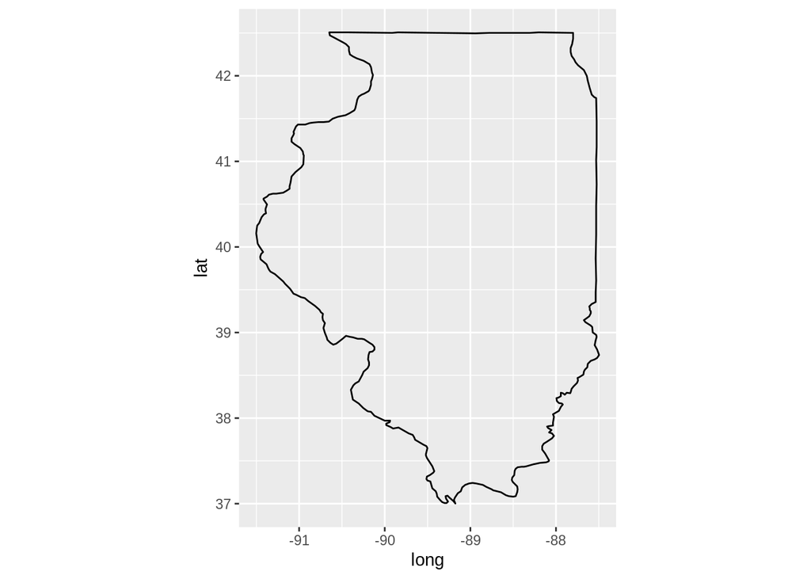

```r
IL.basemap+geom_path()
```

Yep! If I had slowed down to read THE FIRST TWO SENTENCES on the [help page](https://ggplot2.tidyverse.org/reference/geom_path.html) I would have known the issue. But – purposely substituting `path` with `line` does offer some potential artistic representations. I recognize where `geom_line` would be helpful for, say, time-sequenced data if the observations are not ordered in the data frame. It’ll do that ordering for you.

To that end: what if the ordering was purposefully scrambled??

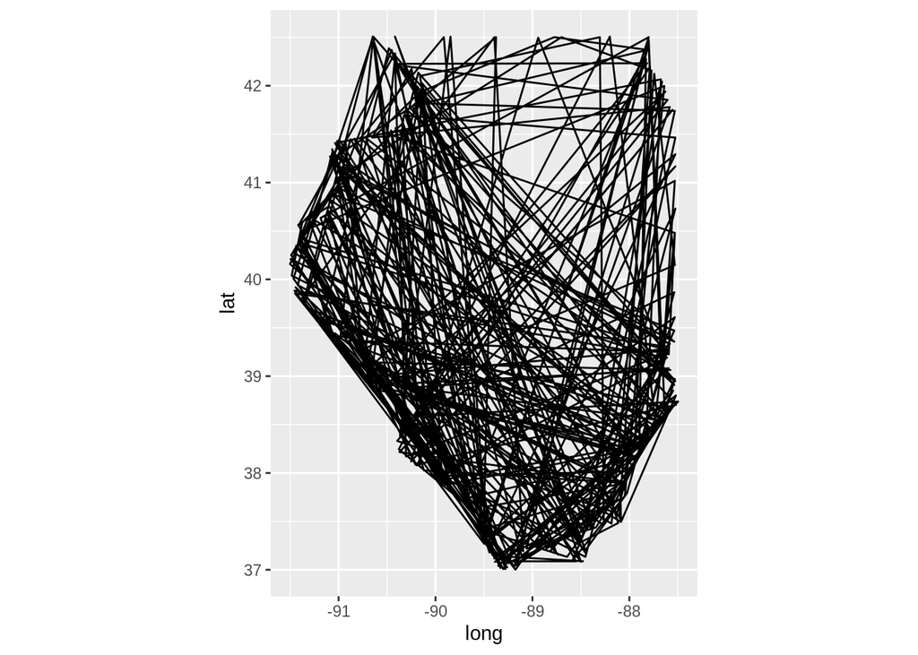

```r
#---scramble the dots in the Illinois data frame
IL.scrambled<-IL[sample(1:nrow(IL)),]

#---plot...
ggplot(
    #---...scrambled Illinois!!
    data=IL.scrambled,
    #---aesthetics
    aes(
        #---long and lat
        x=long,
        y=lat
    )
)+
#---don't mess with that aspect ratio!!!
coord_fixed()+
#---line, err path geometry
geom_path()
```

Not bad – but, what about other states using this model? Let’s randomly select one of the US states, then scramble the dots of the border, then connect the dots to draw a map. No name given – I wonder if I’ll be able to tell what state it is??

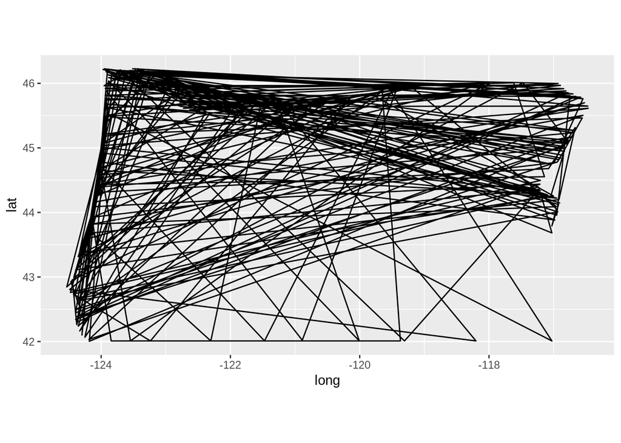

```r
#---find all the states available to me, then pick one at random
state.names<-unique(states$region)
sample(state.names,1)->secret.state

#---extract border data for my 'secret state'
secret.state.border<-subset(states,region==secret.state)

#---scramble that data
secret.state.border<-secret.state.border[sample(1:nrow(secret.state.border)),]

#---plot...
ggplot(
    #---...secret scrambled state!
    data=secret.state.border,
    #---aesthetics
    aes(x=long, y=lat)
)+
#---aspect ratio!!!
coord_fixed()+
#---line, err path geometry
geom_path()
```

Can you figure it out? I think I just discovered a game that needs to happen. So – I’ll get back to that JSON data with the 1000 cities, but I’m gonna riff on this for now. To be continued…

[SCRIPT FOR ‘SPAGHETTI STATE’ MAP FROM THIS SESSION](https://github.com/wj107/Learning/scripts/L1-spaghetti_state.R)